# PCOS Sentiment Analysis

Aditi Gajjar

1/27/2022

# Introduction

The idea for the topic of this project came from a personal experience I had at the doctor’s office–being diagnosed with Polycystic Ovarian Syndrome (PCOS).

When my doctor diagnosed me with PCOS, I was instructed to lose weight. Dealing with the diagnosis and the burden of needing to lose weight was a stressful experience for me, and I found myself with a lack of mental health resources to cope. Research shows that about 10% of women suffer from this condition, which made me wonder what others’ attitudes were towards having to lose weight.

The internet has become a hub for sharing information and exchanging advice conveniently and anonymously. Forums such as Reddit provide a platform for people to share experiences and learn from others experiences. Using public posts on Reddit, I wanted to explore attitudes towards PCOS diagnoses, particularly pertaining to weight and body image, to gauge a need for better mental health support from medical professionals when diagnosing PCOS.

# Data Story

To address my research question, the first step was to scrape data on PCOS experiences from Reddit. To do this, I used the Reddit API, a safe, convenient, and legal method to extract data from the website. Note that each topic within Reddit is referred to as “subreddit,” which are usually linked to Reddit pages where members discuss and post within the realm of the topic. Within a subreddit, users can post using a tag, called a “flair,” to organize the categories of discussions that are relevant to each other. Using Python and guidance from this article, I was able to extract the posts that had a flair of “weight” within the PCOS subreddit. The rest of this research utilized R (2020).

There were 248 posts total in the weight flair of the PCOS subreddit on January 21, 2022, and I was able to scrape all of them. The variables of interest I kept were:

- ID (as opposed to a username for the account that posted)
- number of comments
- title of the post
- body or text of the post
- a URL to the post
- number of upvotes
- top comment
- creation date

Upon an initial glance, it looked like many posts used emojis, SMS style-talk, and misspellings. However, given the large amount of working data I had, I chose to sacrifice the instances where those words would influence my final analysis. This reduced the size of my data from 33,540 to 12,734 words.

## Data Exploration

Once I imported the dataset into R, I needed to clean the data. To do this, I split the post’s body into separate words and removed the “stop words” or extra words that don’t convey any emotions. I used the R `stop_words` dataset and an `antijoin()` function to remove these words.

For the actual sentiment analysis itself, there were two main lexicons I chose to explore: NRC (or Non-Commercial Research Use) and Afinn. The NRC lexicon based sentiment analysis resulted in exact sentiments in the form of words, such as “joy,” and “positive,” or “negative.” On the other hand, Afinn sentiment analysis results in a number system. Under Afinn, the more negative a word, the more negative the assigned value, and the more positive the number, the more positive the assigned value.

### NRC: In-depth Look at Sentiment

For the NRC sentiment analysis, I split the body of each of the posts and found the sentient of each separate word. It’s important to note that the algorithm applied every possible sentiment to a corresponding word, creating replicates of words used. After applying the NRC lexicon, my resulting dataset is as follows in Table 2.1.

|  | word | post | sentiment |
| --- | --- | --- | --- |
| 1 | gaining | 0 | positive |
| 2 | finally | 0 | anticipation |
| 3 | time | 0 | anticipation |
| 4 | feeling | 0 | anger |
| 5 | weight | 0 | anticipation |
| 6 | loss | 0 | anger |
| 7 | impossible | 0 | negative |
| 8 | advice | 0 | trust |
| 9 | dinner | 1 | positive |
| 10 | watch | 1 | anticipation |

[output cut: 646 more lines]

Table 2.1

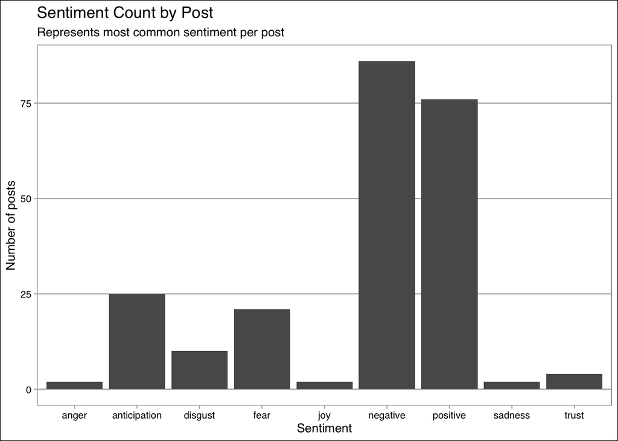

Figure 2.1

Without taking the posts in to account, the overall sentiments were distributed as follows in Figure 2.2. As a reminder, each word could have multiple associated sentiments. Thus, the y-axis here is not reflective of the number of posts, but rather the number of words classified under each sentiment, where a word can appear in multiple bars.

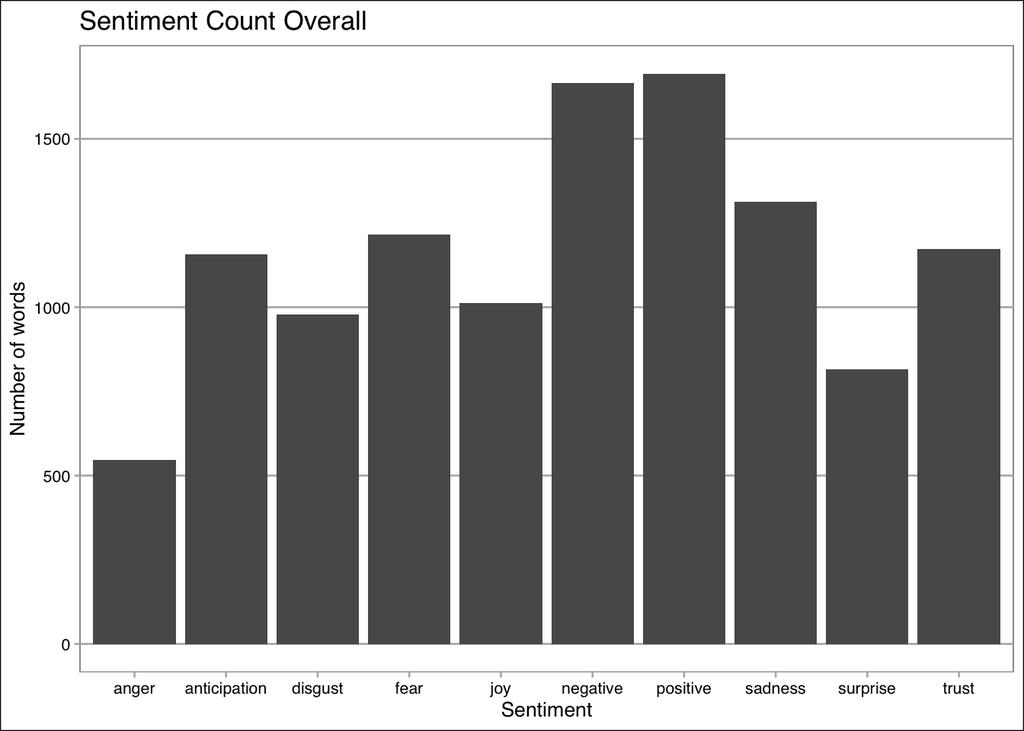

Figure 2.2

### AFINN: Numerical Analysis on Sentiment

A quick look at the Afinn lexicon:

|  | word | value |
| --- | --- | --- |
| 1 | abandon | -2 |
| 2 | abandoned | -2 |
| 3 | abandons | -2 |
| 4 | abducted | -2 |
| 5 | abduction | -2 |
| 6 | abductions | -2 |
| 7 | abhor | -3 |
| 8 | abhorred | -3 |
| 9 | abhorrent | -3 |
| 10 | abhors | -3 |

[output cut: 2467 more lines]

Table 3.1

For the Afinn sentiment analysis, I again split the body and found the rating of each of the words, but since these were numerical values, I was able to summarize these values with the mean to capture the overall sentiment of the post.

|  | word | post | value |
| --- | --- | --- | --- |
| 1 | gaining | 0 | 2 |
| 2 | feeling | 0 | 1 |
| 3 | loss | 0 | -3 |
| 4 | feeling | 0 | 1 |
| 5 | losing | 1 | -3 |
| 6 | frustrating | 1 | -2 |
| 7 | wrong | 1 | -2 |
| 8 | frustrated | 1 | -2 |
| 9 | loss | 2 | -3 |
| 10 | cleaner | 2 | 2 |

[output cut: 1676 more lines]

Table 3.2

After performing the sentiment analysis, I found that there were 77 posts with positive means, 132 with negative means, and 16 with neutral means (with Afinn values of exactly 0).

## Comparison of Afinn & NRC

After using both, I found that Afinn resulted in more accurate findings. NRC, perhaps due to the fact that we are only using the most common sentiment without any context, seemed to often misrepresent the post’s sentiment. For example, while NRC accurately classified the following post as positive:

```
## [1] "I know it’s not a lot, but after gaining 30 this summer after my wedding, I’m so happy to see the scale going down instead of up! This is over the past 3.5 weeks, I’ve been doing low-ish carb(healthy carbs like brown rice, sweet potato etc), dairy free(but have been for years, super lactose …
```

## Findings

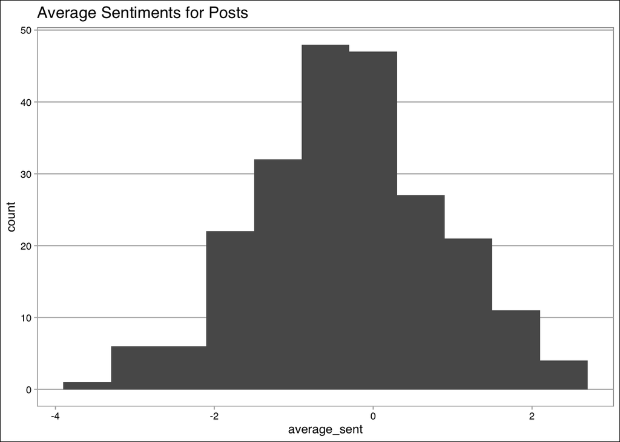

Figure 5.1

```
## [1] "Hi! I’m very curious for anyone that has PCOS and smokes marijuana. How has it affected you? Does it really help control your appetite and cravings?"
```

## Conclusion

Despite seeing some variation in sentiment, most PCOS subreddit posts consistently convey negative sentiments about weight. This tells us that PCOS patients, at least those likely to use the internet as a hub for discussing their condition, have a negative experience with their weight associated with their diagnoses. Therefore, doctors need to be more sympathetic and willing to provide emotional or mental support when talking about weight and weight loss. (One such solution could be setting up mental health counseling or offering those services to women that receive a PCOS diagnosis.)

## Citations

R Core Team (2020). R: A language and environment for statistical computing. R Foundation for Statistical Computing, Vienna, Austria. URL https://www.R-project.org/.